# stationarity – Data Science Lab

A Stationary series is one whose statistical properties such as mean, variance, covariance, and standard deviation do not vary with time, or these stats properties are not a function of time. In other words, stationarity in Time Series also means series without a **Trend** or **Seasonal** components.

- Constant mean
- Constant Variance
- Constant covariance

Visual Signs of Non-Stationarity 👀 - Trend: A clear upward or downward movement over time. The mean is not constant.

- Seasonality: A pattern that repeats at regular intervals (e.g., yearly, monthly, weekly).
- Varying Variance: The spread of the data points increases or decreases over time, making the series appear wider or narrower

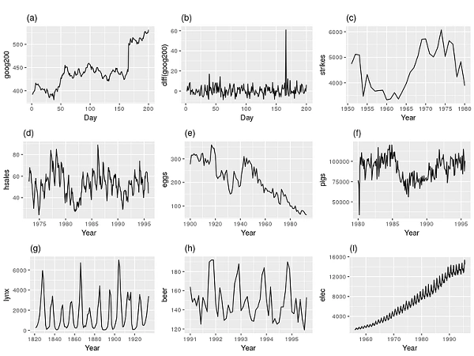

image.png

- Seasonality can be observed in series (d), (h), and (i)
- The trend can be observed in series (a), (c), (e), (f), and (i)
- Series (b) and (g) are stationary

ADF Test: - Null Hypothesis (HO): Series is non-stationary - Alternate Hypothesis(HA): Series is stationary

Reject the null hypothesis if p-value < 0.05

KPSS Test - Null Hypothesis (HO): Series is trend stationary - Alternate Hypothesis(HA): Series is non-stationary

```python
# Load the libraries
import numpy as np
import pandas as pd
import matplotlib.pyplot as plt
```

```python
# Using airline passenger dataset (monthly totals)
url = 'https://raw.githubusercontent.com/jbrownlee/Datasets/master/airline-passengers.csv'
df = pd.read_csv(url, parse_dates=['Month'], index_col='Month')
df
```

| Month | Passengers |
| --- | --- |
| 1949-01-01 | 112 |
| 1949-02-01 | 118 |
| 1949-03-01 | 132 |
| 1949-04-01 | 129 |
| 1949-05-01 | 121 |
| ... | ... |
| 1960-08-01 | 606 |
| 1960-09-01 | 508 |
| 1960-10-01 | 461 |
| 1960-11-01 | 390 |
| 1960-12-01 | 432 |

144 rows × 1 columns

```python
df["Passengers"].plot(figsize = (12,5))
```

[figure not shown]

```python
from statsmodels.tsa.stattools import adfuller
```

```python
dftest = adfuller(df["Passengers"], autolag='AIC')
```

```python
dfoutput = pd.Series(dftest[0:4], index=['Test Statistic','p-value','#Lags Used','Number of Observations Used'])
for key,value in dftest[4].items():
  dfoutput['Critical Value (%s)'%key] = value
dfoutput
```

|  | 0 |
| --- | --- |
| Test Statistic | 0.815369 |
| p-value | 0.991880 |
| #Lags Used | 13.000000 |
| Number of Observations Used | 130.000000 |
| Critical Value (1%) | -3.481682 |
| Critical Value (5%) | -2.884042 |
| Critical Value (10%) | -2.578770 |

**dtype:** float64

```python
from statsmodels.tsa.stattools import kpss
```

```python
kpsstest = kpss(df["Passengers"], regression='c', nlags="auto")
```

```python
kpss_output = pd.Series(kpsstest[0:3], index=['Test Statistic','p-value','#Lags Used'])
for key,value in kpsstest[3].items():
  kpss_output['Critical Value (%s)'%key] = value
kpss_output
```

|  | 0 |
| --- | --- |
| Test Statistic | 1.651312 |
| p-value | 0.010000 |
| #Lags Used | 8.000000 |
| Critical Value (10%) | 0.347000 |
| Critical Value (5%) | 0.463000 |
| Critical Value (2.5%) | 0.574000 |
| Critical Value (1%) | 0.739000 |

**dtype:** float64

```python
def kpss_test(timeseries):
    print ('Results of KPSS Test:')
    kpss_output = pd.Series(kpsstest[0:3], index=['Test Statistic','p-value','#Lags Used'])
    for key,value in kpsstest[3].items():
        kpss_output['Critical Value (%s)'%key] = value
    print (kpss_output)
```

The following are the possible outcomes of applying both tests.

- Case 1: Both tests conclude that the given series is stationary – The series is stationary
- Case 2: Both tests conclude that the given series is non-stationary The series is non-stationary
- Case 3: ADF concludes non-stationary, and KPSS concludes stationary The series is trend stationary. To make the series strictly stationary, we need to remove the trend in this case. Then we check the detrended series for stationarity.
- Case 4: ADF concludes stationary, and KPSS concludes non-stationary The series is difference stationary. Differencing is to be used to make series stationary. Then we check the differenced series for stationarity.

```python
import pandas as pd
import numpy as np
import matplotlib.pyplot as plt
from statsmodels.tsa.stattools import adfuller, kpss
from sklearn.linear_model import LinearRegression
```

```python
# Plot original series
df['Passengers'].plot(title='Original Airline Passenger Data', figsize=(10, 4))
plt.grid()
plt.show()
```

[figure not shown]

```python
# Step 1: Fit linear regression (trend) using sklearn
X = np.arange(len(df)).reshape(-1, 1)       # Time as feature
y = df['Passengers'].values                     # Passenger values
model = LinearRegression().fit(X, y)
trend = model.predict(X)
```

```python
df['detrended'] = y - model.predict(X)
```

```python
# Plot detrended series
df['detrended'].plot(title='Detrended Series (Linear Trend Removed)', figsize=(10, 4))
plt.grid()
plt.show()
```

[figure not shown]

```python
# Step 2: Stationarity Tests
# ADF Test
adf_orig_p = adfuller(df['Passengers'])[1]
adf_det_p = adfuller(df['detrended'])[1]

# KPSS Test
kpss_orig_p = kpss(df['Passengers'], regression='ct')[1]     # trend + constant
kpss_det_p = kpss(df['detrended'], regression='c')[1]   # constant only

# Step 3: Print Results
print("📊 Stationarity Test Results")
print(f"ADF (Original):     p = {adf_orig_p:.4f} → {'Non-stationary' if adf_orig_p > 0.05 else 'Stationary'}")
print(f"KPSS (Original):    p = {kpss_orig_p:.4f} → {'Non-stationary' if kpss_orig_p < 0.05 else 'Stationary'}")
print(f"ADF (Detrended):    p = {adf_det_p:.4f} → {'Non-stationary' if adf_det_p > 0.05 else 'Stationary'}")
print(f"KPSS (Detrended):   p = {kpss_det_p:.4f} → {'Non-stationary' if kpss_det_p < 0.05 else 'Stationary'}")
```

```
📊 Stationarity Test Results
ADF (Original):     p = 0.9919 → Non-stationary
KPSS (Original):    p = 0.1000 → Stationary
ADF (Detrended):    p = 0.2437 → Non-stationary
KPSS (Detrended):   p = 0.1000 → Stationary
```